# Instructions

- Some parts of the code are already done for you
- You need to execute all the cells
- You need to add the code where ever you see `"#### Add your code here ####"`
- Marks are mentioned along with the cells

# Face Mask Segmentation

Task is to predict the boundaries(mask) around the face in a given image.

## Dataset

### Mount Google drive if you are using google colab

- We recommend using Google Colab as you can face memory issues and longer runtimes while running on local

```python
from google.colab import drive
drive.mount('/content/drive')
```

### Change current working directory to project folder (1 mark)

```python
import os
project_path = '/content/drive/My Drive/AIML/Labs/CVData'
os.chdir(project_path)
```

```python
ls
```

```
images.npy     model-0.30.h5  model-0.36.h5  model-0.44.h5
model-0.28.h5  model-0.33.h5  model-0.39.h5  result.png
```

```python
pwd
```

```
'/content/drive/My Drive/AIML/Labs/CVData'
```

### Load the "images.npy" file (2 marks)

- This file contains images with details of bounding boxes

```python
import numpy as np
data = np.load(project_path + '/images.npy',allow_pickle=True)
```

```python
data.shape
```

```
(409, 2)
```

### Check one sample from the loaded "images.npy" file (2 marks)

Hint - print data[10][1]

[figure not shown]

```python
import matplotlib.pyplot as plt
plt.imshow(data[12][0])
```

```python
print(data[12][0].shape)
```

```
(3423, 5000, 3)
```

```python
print(data[12][1])
```

```
[{'label': ['Face'], 'notes': '', 'points': [{'x': 0.027709861450692746, 'y': 0.10357142857142858}, {'x': 0.17277913610431947, 'y': 0.38095238095238093}], 'imageWidth': 5000, 'imageHeight': 3423}, {'label': ['Face'], 'notes': '', 'points': [{'x': 0.20048899755501223, 'y': 0.22023809523809523}, {'x':…
```

```python
labelData=data[12][1]

for key in labelData:
    print (key['label'][0])
    print (key['points'][0])
    print (key['points'][1])
    print ('imageWidth',key['imageWidth'])
    print ('imageHeight',key['imageHeight'])
    #print (labelData[key])
```

```
Face
{'x': 0.027709861450692746, 'y': 0.10357142857142858}
{'x': 0.17277913610431947, 'y': 0.38095238095238093}
imageWidth 5000
imageHeight 3423
Face
{'x': 0.20048899755501223, 'y': 0.22023809523809523}
{'x': 0.3154034229828851, 'y': 0.4845238095238095}
imageWidth 5000
imageHeight 3423
Face
{'x': 0.530562347188264, 'y': 0.11666666666666667}
{'x': 0.6674816625916871, 'y': 0.40595238095238095}
imageWidth 5000
imageHeight 3423
Face
{'x': 0.6764466177669112, 'y': 0.2904761904761905}
{'x': 0.7685411572942136, 'y': 0.49166666666666664}
imageWidth 5000
imageHeight 3423
Face
{'x': 0.778321108394458, 'y': 0.1773809523809524}
{'x': 0.9176854115729421, 'y': 0.42142857142857143}
imageWidth 5000
imageHeight 3423
```

### Set image dimensions (2 marks)

- Initialize image height, image width with value: 224

```python
IMAGE_WIDTH = 224
IMAGE_HEIGHT = 224
```

### Create features and labels

- Here feature is the image
- The label is the mask
- Images will be stored in "X_train" array
- Masks will be stored in "masks" array

```python
import cv2
from tensorflow.keras.applications.mobilenet import preprocess_input

masks = np.zeros((int(data.shape[0]), IMAGE_HEIGHT, IMAGE_WIDTH))
X_train = np.zeros((int(data.shape[0]), IMAGE_HEIGHT, IMAGE_WIDTH, 3))
for index in range(data.shape[0]):
    img = data[index][0]
    img = cv2.resize(img, dsize=(IMAGE_HEIGHT, IMAGE_WIDTH), interpolation=cv2.INTER_CUBIC)
    try:
      img = img[:, :, :3]
    except:
      continue
    X_train[index] = preprocess_input(np.array(img, dtype=np.float32))
    for i in data[index][1]:
        x1 = int(i["points"][0]['x'] * IMAGE_WIDTH)
        x2 = int(i["points"][1]['x'] * IMAGE_WIDTH)
        y1 = int(i["points"][0]['y'] * IMAGE_HEIGHT)
        y2 = int(i["points"][1]['y'] * IMAGE_HEIGHT)
        masks[index][y1:y2, x1:x2] = 1
```

### Print the shape of X_train and mask array (2 marks)

```python
print(X_train.shape)
```

```
(409, 224, 224, 3)
```

```python
print(masks.shape)
```

```
(409, 224, 224)
```

### Print a sample image and image array

```
Clipping input data to the valid range for imshow with RGB data ([0..1] for floats or [0..255] for integers).
```

[output not shown]

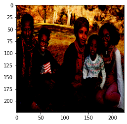

```python
from matplotlib import pyplot
n = 12
print(X_train[n])
pyplot.imshow(X_train[n])
```

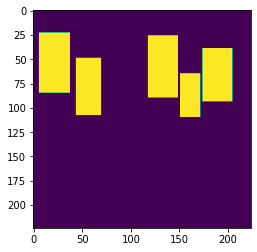

```python
pyplot.imshow(masks[n])
```

## Create the model (10 marks)

- Add MobileNet as model with below parameter values
  - input_shape: IMAGE_HEIGHT, IMAGE_WIDTH, 3
  - include_top: False
  - alpha: 1.0
  - weights: "imagenet"
- Add UNET architecture layers
  - This is the trickiest part of the project, you need to research and implement it correctly

```python
from tensorflow.keras.applications.mobilenet import MobileNet
from tensorflow.keras.layers import Conv2D, Activation, BatchNormalization
from tensorflow.keras.layers import UpSampling2D, Input, Concatenate
from tensorflow.keras.models import Model

ALPHA = 1.0 # Width hyper parameter for MobileNet (0.25, 0.5, 0.75, 1.0). Higher width means more accurate but slower

def create_model(trainable=True):
    inputs = Input(shape=(IMAGE_HEIGHT, IMAGE_WIDTH, 3), name="input_image")
    model = MobileNet(input_tensor=inputs, include_top=False, alpha=ALPHA, weights="imagenet")
    print(model.summary())

    skip_connection_names = ["input_image","conv_pw_1_relu", "conv_pw_3_relu", "conv_pw_5_relu","conv_pw_11_relu"] # From Pre Trained Model #"input_image",
    pre_trained_output = model.get_layer("conv_pw_13_relu").output #output of 7*7


    #Feature Output
    f = [7, 14, 28, 56, 112]
    x = pre_trained_output

    for i in range(1, len(skip_connection_names)+1, 1):
        layer=model.get_layer(skip_connection_names[-i])
        layer.trainable = trainable


        x_skip = layer.output #Starting with -i, as to upscale to 14*14 image from 7*7 images

        print(' name of the skip connections',x_skip)

        x = UpSampling2D((2, 2))(x)
        x = Concatenate()([x, x_skip])

        x = Conv2D(f[-i], (3, 3), padding="same")(x)
        x = BatchNormalization()(x)
        x = Activation("relu")(x)

        x = Conv2D(f[-i], (3, 3), padding="same")(x)
        x = BatchNormalization()(x)
        x = Activation("relu")(x)

    x = Conv2D(1, (1, 1), padding="same")(x)
    x = Activation("sigmoid")(x)

    return Model(inputs=model.input, outputs=x)
```

### Call the create_model function

```python
# Give trainable=False as argument, if you want to freeze lower layers for fast training (but low accuracy)
model = create_model(False)

# Print summary
model.summary()
```

[output not shown]

[output cut: 405 more lines]

```
__________________________________________________________________________________________________
conv2d_53 (Conv2D)              (None, 224, 224, 7)  448         activation_52[0][0]
__________________________________________________________________________________________________
batch_normalization_49 (BatchNo (None, 224, 224, 7)  28          conv2d_53[0][0]
__________________________________________________________________________________________________
activation_53 (Activation)      (None, 224, 224, 7)  0           batch_normalization_49[0][0]
__________________________________________________________________________________________________
conv2d_54 (Conv2D)              (None, 224, 224, 1)  8           activation_53[0][0]
__________________________________________________________________________________________________
activation_54 (Activation)      (None, 224, 224, 1)  0           conv2d_54[0][0]
==================================================================================================
Total params: 5,174,214
Trainable params: 5,151,458
Non-trainable params: 22,756
__________________________________________________________________________________________________
```

Reference: https://www.youtube.com/watch?v=kXsBbDGUbpw

https://github.com/nikhilroxtomar/Unet-with-Pretrained-Encoder/blob/master/U-Net_with_Pretrained_MobileNetV2_as_Encoder.ipynb

### Define dice coefficient function (10 marks)

- Create a function to calculate dice coefficient

```python
def dice_coefficient(y_true, y_pred):
    numerator = 2 * tensorflow.reduce_sum(y_true * y_pred)
    denominator = tensorflow.reduce_sum(y_true + y_pred)

    return numerator / (denominator + tensorflow.keras.backend.epsilon())
```

### Define loss

```python
from tensorflow.keras.losses import binary_crossentropy
from tensorflow.keras.backend import log, epsilon
def loss(y_true, y_pred):
    return binary_crossentropy(y_true, y_pred) - log(dice_coefficient(y_true, y_pred) + epsilon())
```

### Compile the model (3 marks)

- Complie the model using below parameters
  - loss: use the loss function defined above
  - optimizers: use Adam optimizer
  - metrics: use dice_coefficient function defined above

```python
from tensorflow.keras.optimizers import Adam
from tensorflow.keras.losses import binary_crossentropy

optimizer = Adam(lr=1e-4, beta_1=0.9, beta_2=0.999, epsilon=None, decay=0.0, amsgrad=False)
model.compile(loss=loss, optimizer=optimizer, metrics=[dice_coefficient])
```

### Define checkpoint and earlystopping

```python
from tensorflow.keras.callbacks import ModelCheckpoint, EarlyStopping, ReduceLROnPlateau
checkpoint = ModelCheckpoint("model-{loss:.2f}.h5", monitor="loss", verbose=1, save_best_only=True,
                             save_weights_only=True, mode="min", period=1)
stop = EarlyStopping(monitor="loss", patience=5, mode="min")
reduce_lr = ReduceLROnPlateau(monitor="loss", factor=0.2, patience=5, min_lr=1e-6, verbose=1, mode="min")
```

```
WARNING:tensorflow:`period` argument is deprecated. Please use `save_freq` to specify the frequency in number of batches seen.
```

### Fit the model (3 marks)

- Fit the model using below parameters
  - epochs: you can decide
  - batch_size: 1
  - callbacks: checkpoint, reduce_lr, stop

```python
X_train.shape
```

```
(409, 224, 224, 3)
```

```python
print(masks.shape)
```

```
(409, 224, 224)
```

```python
import cv2
#masks=cv2.resize(masks[0], (28, 28))
masks.shape
```

```
(409, 224, 224)
```

```python
%tensorflow_version 2.x
import tensorflow
tensorflow.__version__
```

```
'2.3.0'
```

```python
model.fit(X_train, masks, callbacks = [checkpoint, stop, reduce_lr], validation_split=.2, epochs=20, batch_size=1, verbose=1)
```

```
Epoch 00001: loss improved from inf to 2.00099, saving model to model-2.00.h5
Epoch 00002: loss improved from 2.00099 to 1.62874, saving model to model-1.63.h5
Epoch 00003: loss improved from 1.62874 to 1.45927, saving model to model-1.46.h5
Epoch 00004: loss improved from 1.45927 to 1.31578, saving model to model-1.32.h5
Epoch 00005: loss improved from 1.31578 to 1.18873, saving model to model-1.19.h5
Epoch 00006: loss improved from 1.18873 to 1.07095, saving model to model-1.07.h5
Epoch 00007: loss improved from 1.07095 to 0.96533, saving model to model-0.97.h5
Epoch 00008: loss improved from 0.96533 to 0.86843, saving model to model-0.87.h5
Epoch 00009: loss improved from 0.86843 to 0.78394, saving model to model-0.78.h5
Epoch 00010: loss improved from 0.78394 to 0.70433, saving model to model-0.70.h5
Epoch 00011: loss improved from 0.70433 to 0.63786, saving model to model-0.64.h5
Epoch 00012: loss improved from 0.63786 to 0.57793, saving model to model-0.58.h5
Epoch 00013: loss improved from 0.57793 to 0.52104, saving model to model-0.52.h5
Epoch 00014: loss improved from 0.52104 to 0.47330, saving model to model-0.47.h5
Epoch 00015: loss improved from 0.47330 to 0.43633, saving model to model-0.44.h5
Epoch 00016: loss improved from 0.43633 to 0.39172, saving model to model-0.39.h5
Epoch 00017: loss improved from 0.39172 to 0.35590, saving model to model-0.36.h5
Epoch 00018: loss improved from 0.35590 to 0.32613, saving model to model-0.33.h5
Epoch 00019: loss improved from 0.32613 to 0.29862, saving model to model-0.30.h5
Epoch 00020: loss improved from 0.29862 to 0.27727, saving model to model-0.28.h5
```

```
<tensorflow.python.keras.callbacks.History at 0x7efb3093ec18>
```

### Get the predicted mask for a sample image (5 marks)

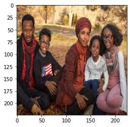

```python
sample_image=data[12][0]
image = cv2.resize(sample_image, (IMAGE_WIDTH, IMAGE_HEIGHT))
plt.imshow(image)
```

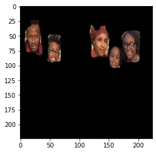

```python
sample_image=data[12][0]

import matplotlib.pyplot as plt
image = cv2.resize(sample_image, (IMAGE_WIDTH, IMAGE_HEIGHT))
feat_scaled = preprocess_input(np.array(image, dtype=np.float32))

pred_mask = cv2.resize(1.0*(model.predict(x=np.array([feat_scaled]))[0] > 0.5), (IMAGE_WIDTH,IMAGE_HEIGHT))
#plt.imshow(pred_mask)

image2 = image

image2[:,:,0] = pred_mask*image[:,:,0]
image2[:,:,1] = pred_mask*image[:,:,1]
image2[:,:,2] = pred_mask*image[:,:,2]

mask_image = image2

plt.imshow(mask_image)
```

### Impose the mask on the image (5 marks)

[figure not shown]

```python
import cv2

# Load images
bg     = cv2.resize(data[12][0], (IMAGE_WIDTH, IMAGE_HEIGHT))
mask   = cv2.resize(mask_image,(224,224))

# white out the faces we want to overlay
bg[mask>0]=255

#bg += mask*(mask>0)

cv2.imwrite('result.png',bg)
out_image=cv2.imread(project_path + '/result.png')
plt.imshow(out_image)
```